# Logistic Regression on Amazon Fine FOod Reviews

```python
#importing necessary packages
import sqlite3
import pandas as pd
import numpy as np
from sklearn.preprocessing import StandardScaler
import matplotlib.pyplot as plt
import seaborn as sns
import nltk
from sklearn.feature_extraction.text import CountVectorizer,TfidfVectorizer
import pickle
import sklearn.cross_validation
from sklearn.model_selection import train_test_split
from collections import Counter
from sklearn.metrics import accuracy_score
from sklearn import cross_validation
```

```python
from sklearn.metrics import precision_score,recall_score,f1_score,confusion_matrix,roc_auc_score,roc_curve
```

## Reading already Cleaned, Preprocessed data from database

After removing stopwords, punctuations, meaningless characters, HTML tags from Text and done stemming. Using it directly as it was alredy done in prevoius assignment

```python
#Reading
conn= sqlite3.connect('cleanedTextData.sqlite')
data= pd.read_sql_query('''
SELECT * FROM Reviews
''',conn)
data=data.drop('index',axis=1)
data.shape
```

```
(364171, 11)
```

```python
data.columns
```

```
Index(['Id', 'ProductId', 'UserId', 'ProfileName', 'HelpfulnessNumerator',
       'HelpfulnessDenominator', 'Score', 'Time', 'Summary', 'Text',
       'CleanedText'],
      dtype='object')
```

```python
data['CleanedText'].head(3)
```

```
0    witti littl book make son laugh loud recit car...
1    rememb see show air televis year ago child sis...
2    beetlejuic well written movi everyth act speci...
Name: CleanedText, dtype: object
```

## Sorting on the basis of 'Time' and taking top 100k pts

This data has time attribute so it will be reasonable to do time based splitting instead of random splitting.

So, before splitting we have to sort our data according to time and here we are taking 100k points from our dataset(population)

```python
data["Time"] = pd.to_datetime(data["Time"], unit = "ms")
data = data.sort_values(by = "Time")
```

```python
#latest 100k points according to time
data= data[:100000]
len(data)
```

```
100000
```

## Splitting data into train70% test30%

Splitting our data into train and test data.

- train data will train our ML model
- cross validataion data will be for determining our hyperparameter
- test data will tell how Generalized our model is
- dataframes after splitting:- traindata, testdata

```python
traindata, testdata= train_test_split(data, test_size= 0.3, shuffle= False,stratify= None)
print(len(traindata),len(testdata))
```

```
70000 30000
```

```python
Xtrain,Xtest= traindata['CleanedText'],testdata['CleanedText']
Ytrain,Ytest= traindata['Score'],testdata['Score']
```

```python
# converting positive to 1 and negative to 0
Ytrain=Ytrain.map(lambda x:1 if x=='Positive' else 0)
Ytest=Ytest.map(lambda x:1 if x=='Positive' else 0)
```

Taking Text and score(class) as sequences

- traindata -> Xtrain, Ytrain
- testdata -> Xtest, Ytest

#### Function for testing porformance when different C and penalty passed as parameters with train and test data

```python
# this will take c, penalty, test, train data as parameters and compute different accuracies
# this function was made because this code will be used many times
from sklearn.linear_model import LogisticRegression
def myLogReg(c,penalti,xtrn,xtst):

    #Testing performance on Test data
    clf = LogisticRegression(C= c, penalty= penalti)
    clf.fit(xtrn,Ytrain)
    y_train_pred= clf.predict(xtrn)
    y_pred = clf.predict(xtst)
    print("AUC score on test set: %0.3f%%"%(roc_auc_score(Ytest, y_pred)*100))
    print("Accuracy on test set: %0.3f%%"%(accuracy_score(Ytest, y_pred)*100))
    print("Precision on test set: %0.3f"%(precision_score(Ytest, y_pred)*100))
    print("Recall on test set: %0.3f"%(recall_score(Ytest, y_pred)*100))
    print("F1-Score on test set: %0.3f"%(f1_score(Ytest, y_pred)*100))
    print("Non Zero weights:",np.count_nonzero(clf.coef_))
    fpr_train,tpr_train,ts_train=roc_curve(Ytrain,y_train_pred)
    fpr,tpr,ts=roc_curve(Ytest,y_pred)
    plt.plot(fpr,tpr,label='TEST')
    plt.plot(fpr_train,tpr_train,label='TRAIN')
    plt.xlabel('False positive rate')
    plt.ylabel('True positive rate')
    plt.title('ROC curve')
    plt.legend()
    plt.show()
    print("Confusion Matrix of test set:\n [ [TN  FP]\n [FN TP] ]\n")
    df_cm = pd.DataFrame(confusion_matrix(Ytest, y_pred), range(2),range(2))
    sns.set(font_scale=1.4)#for label size
    sns.heatmap(df_cm, annot=True,annot_kws={"size": 16}, fmt='g')
```

# BOW Vectorization

Bow vectorization is basic technique to convert a text into numerical vector.

- We will build a model on train text using fit-transform
- Then transform (test) text on model build by train text
- Transformed data will be in the form of sparse matrix

```python
# vectorizing X and transforming
bowModel=CountVectorizer()
XtrainBOWV=bowModel.fit_transform(Xtrain.values)
```

```python
XtestBOWV= bowModel.transform(Xtest)
XtestBOWV.shape
```

```
(30000, 39730)
```

```python
#Standardizing vectors
std = StandardScaler(with_mean=False).fit(XtrainBOWV)
XtrainBOWV = std.transform(XtrainBOWV)
XtestBOWV = std.transform(XtestBOWV)
```

## Gridsearch CV on BOW vector for optimal C= 1/lambda

It will be having two cases :-

1. L2 regularization
2. L1 regularization

```python
from sklearn.model_selection import GridSearchCV
from sklearn.linear_model import LogisticRegression
from sklearn.model_selection import RandomizedSearchCV
```

```python
logreg=LogisticRegression()
gridSearchParam= {'C':[10**4,10**2,10,1,10**-1,10**-2,10**-4]}
gridSearch= GridSearchCV(logreg,gridSearchParam,cv=10,scoring='roc_auc',n_jobs=-1)
gridSearch.fit(XtrainBOWV,Ytrain)
print(gridSearch.best_estimator_)
print('Best Hyperparameter is ',gridSearch.best_params_)
print('Best auc score is ',gridSearch.best_score_)
```

```
LogisticRegression(C=0.01, class_weight=None, dual=False, fit_intercept=True,
          intercept_scaling=1, max_iter=100, multi_class='ovr', n_jobs=1,
          penalty='l2', random_state=None, solver='liblinear', tol=0.0001,
          verbose=0, warm_start=False)
Best Hyperparameter is  {'C': 0.01}
Best auc score is  0.8743194688817856
```

```
Text(0.5,1,'Auc score vs C')
```

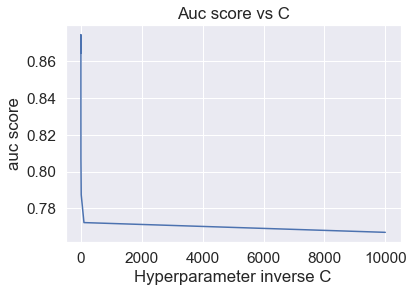

```python
scores = [x[1] for x in gridSearch.grid_scores_]
parameters= gridSearch.param_grid['C']
plt.plot(parameters,scores)
plt.xlabel('Hyperparameter inverse C')
plt.ylabel('auc score')
plt.title('Auc score vs C')
```

### Training and testing with L2 Regularization

```
AUC score on test set: 75.875%
Accuracy on test set: 90.123%
Precision on test set: 93.244
Recall on test set: 95.479
F1-Score on test set: 94.348
Non Zero weights: 39730
```

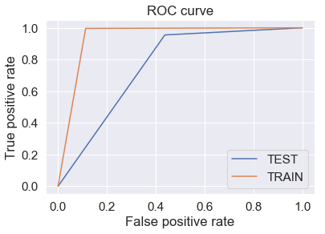

```
Confusion Matrix of test set:
 [ [TN  FP]
 [FN TP] ]
```

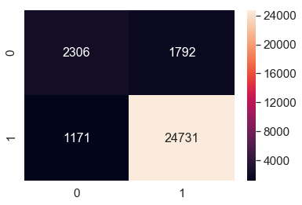

```python
# calling myLogReg function. it was made because it will be used many times
myLogReg(c=0.01,penalti='l2',xtrn=XtrainBOWV,xtst=XtestBOWV)
```

### Training and testing with L1 regularization

```
AUC score on test set: 72.363%
Accuracy on test set: 91.100%
Precision on test set: 92.072
Recall on test set: 98.143
F1-Score on test set: 95.010
Non Zero weights: 3894
```

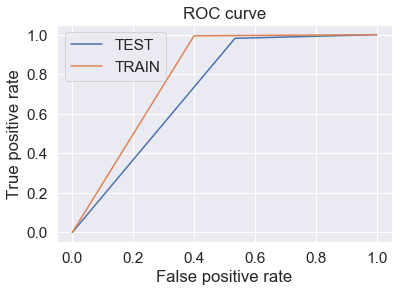

```
Confusion Matrix of test set:
 [ [TN  FP]
 [FN TP] ]
```

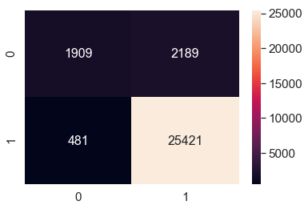

```python
myLogReg(c=0.01,penalti='l1',xtrn=XtrainBOWV,xtst=XtestBOWV)
```

## RandomizedSearch CV on BOW vector for optimal C= 1/lambda

It will be having two cases :-

1. L2 regularization
2. L1 regularization

```python
logreg= LogisticRegression()
randSearchParam= {'C':[1000,500,100,50,10,5,1,0.5,0.1,0.05,0.01,0.005,0.001,0.0005,0.0001]}
randsearch= RandomizedSearchCV(logreg,randSearchParam,cv=10,scoring='roc_auc',n_jobs=-1)
randsearch.fit(XtrainBOWV,Ytrain)
print(randsearch.best_estimator_)
print('Best Hyperparameter is ',randsearch.best_params_)
print('Best auc score is ',gridSearch.best_score_)
```

```
LogisticRegression(C=0.001, class_weight=None, dual=False, fit_intercept=True,
          intercept_scaling=1, max_iter=100, multi_class='ovr', n_jobs=1,
          penalty='l2', random_state=None, solver='liblinear', tol=0.0001,
          verbose=0, warm_start=False)
Best Hyperparameter is  {'C': 0.001}
Best auc score is  0.8743194688817856
```

```
Text(0.5,1,'Auc score vs C')
```

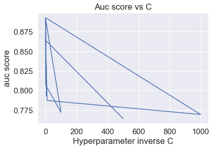

```python
scores = [x[1] for x in randsearch.grid_scores_]
parameters= [x[0]['C'] for x in randsearch.grid_scores_]
plt.plot(parameters,scores)
plt.xlabel('Hyperparameter inverse C')
plt.ylabel('auc score')
plt.title('Auc score vs C')
```

#### Observation

As this is randomize search it will choose hyperparameters ramdomly from given sample space thats why we get zig-zaged lines

### Training and testing with L2 regularization

```
AUC score on test set: 73.976%
Accuracy on test set: 90.977%
Precision on test set: 92.567
Recall on test set: 97.367
F1-Score on test set: 94.907
Non Zero weights: 39730
```

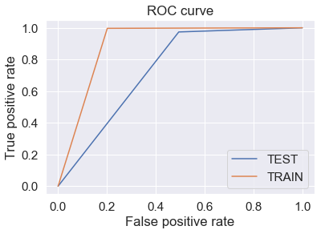

```
Confusion Matrix of test set:
 [ [TN  FP]
 [FN TP] ]
```

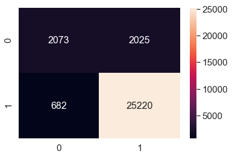

```python
myLogReg(c=0.001,penalti='l2',xtrn=XtrainBOWV,xtst=XtestBOWV)
```

### Training and testing with L1 regularization

```
AUC score on test set: 54.673%
Accuracy on test set: 87.457%
Precision on test set: 87.459
Recall on test set: 99.780
F1-Score on test set: 93.214
Non Zero weights: 50
```

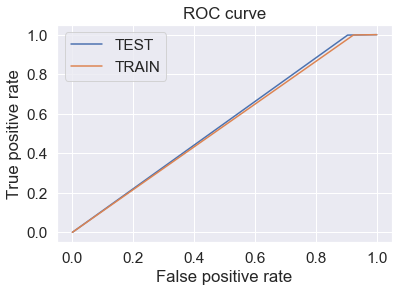

```
Confusion Matrix of test set:
 [ [TN  FP]
 [FN TP] ]
```

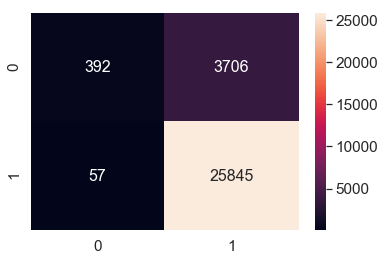

```python
myLogReg(c=0.001,penalti='l1',xtrn=XtrainBOWV,xtst=XtestBOWV)
```

#### Observation

We can see the non-Zero weights droped drastically from around 40k in L2 to 50 in L1 which obviously affect our model hence we got auc score dropped from 73% L2 to 54% in L1

## Change in sparsity with changing 'C' when L1 regularized (taking Bow vect)

This is a test of how sparsity is affected when C is changed when L1 regulairzed

```python
# loop with different c's
for c in [1000,100,10,1,0.1,0.01,0.001]:
    clf = LogisticRegression(C= c, penalty= 'l1',n_jobs=1)
    clf.fit(XtrainBOWV,Ytrain)
    y_pred = clf.predict(XtestBOWV)
    print('\nWhen C is : ',c,'-----------------------------------------------------',sep=' ')
    print("AUC score on test set: %0.3f%%"%(roc_auc_score(Ytest, y_pred)*100))
    print("Accuracy on test set: %0.3f%%"%(accuracy_score(Ytest, y_pred)*100))
    print("F1-Score on test set: %0.3f"%(f1_score(Ytest, y_pred)*100))
    print("Non Zero weights:",np.count_nonzero(clf.coef_))
```

```
When C is :  1000 -----------------------------------------------------
AUC score on test set: 71.940%
Accuracy on test set: 86.413%
F1-Score on test set: 92.110
Non Zero weights: 23555

When C is :  100 -----------------------------------------------------
AUC score on test set: 72.478%
Accuracy on test set: 86.457%
F1-Score on test set: 92.122
Non Zero weights: 17738

When C is :  10 -----------------------------------------------------
AUC score on test set: 73.142%
Accuracy on test set: 86.787%
F1-Score on test set: 92.315
Non Zero weights: 15296

When C is :  1 -----------------------------------------------------
AUC score on test set: 75.383%
Accuracy on test set: 88.440%
F1-Score on test set: 93.308
Non Zero weights: 14242

When C is :  0.1 -----------------------------------------------------
AUC score on test set: 77.850%
Accuracy on test set: 90.927%
F1-Score on test set: 94.803
Non Zero weights: 11234

When C is :  0.01 -----------------------------------------------------
AUC score on test set: 72.343%
Accuracy on test set: 91.100%
F1-Score on test set: 95.011
Non Zero weights: 3886

When C is :  0.001 -----------------------------------------------------
AUC score on test set: 54.673%
Accuracy on test set: 87.457%
F1-Score on test set: 93.214
Non Zero weights: 50
```

#### Observation

We can clearly see that :-

- C decreased -> lambda(c=1/lambda) increased -> nonzero weights decreased -> sparsity increased
- so, as C decreases sparsity increases

## Perturbation test (Multicollinearity)

- First we will train a model on optimal C with l2 regularization
- find and save the weight vector we got from above
- then we will introduce nose to our vectorized data
- then again we will find new weight vector
- then finally we will compare the both and save their corresponding percentage changes
- Finally we will plot the percentiles to check how much multicollinear our data is

```python
#training our model
clf = LogisticRegression(C= 0.01, penalty= 'l2')
clf.fit(XtrainBOWV,Ytrain)
y_pred = clf.predict(XtestBOWV)
print("F1 score on test set: %0.3f%%"%(f1_score(Ytest, y_pred)*100))
print("AUC score on test set: %0.3f%%"%(roc_auc_score(Ytest, y_pred)*100))
print("Non Zero weights:",np.count_nonzero(clf.coef_))
print("Total weights:",len(clf.coef_[0]))
```

```
F1 score on test set: 94.346%
AUC score on test set: 75.863%
Non Zero weights: 39730
Total weights: 39730
```

```python
#Weights before adding random noise
from scipy.sparse import find
weights1 = find(clf.coef_[0])[2]
print(weights1[:20])
```

```
[ 1.00092941e-09  5.42176440e-03  1.41171662e-06  5.29485361e-03
 -8.94430645e-03  2.28240842e-07  1.00489425e-03 -1.26511292e-03
  3.34873056e-03  5.20346943e-04  8.35412507e-03  3.92977137e-02
  1.67122729e-03  2.14251515e-02 -4.59131503e-02  4.51357434e-03
  1.10295558e-04  1.57678030e-02  3.46710592e-03  5.36605929e-03]
```

```python
# adding random noise
XtrainBOWV_t = XtrainBOWV
#Random noise of size same as weights
epsilon = np.random.uniform(low=-0.0001, high=0.0001, size=(find(XtrainBOWV_t)[0].size,))
#Getting the postions(row and column) and value of non-zero datapoints
a,b,c = find(XtrainBOWV_t)

#Introducing random noise to non-zero datapoints
XtrainBOWV_t[a,b] = epsilon + XtrainBOWV_t[a,b]
```

```python
#Training on train data having random noise
clf = LogisticRegression(C= 0.01, penalty= 'l2')
clf.fit(XtrainBOWV_t,Ytrain)
y_pred = clf.predict(XtestBOWV)
print("F1 score on test set: %0.3f%%"%(f1_score(Ytest, y_pred)*100))
print("AUC score on test set: %0.3f%%"%(roc_auc_score(Ytest, y_pred)*100))
print("Non Zero weights:",np.count_nonzero(clf.coef_))
print("Total weights:",len(clf.coef_[0]))
```

```
F1 score on test set: 94.346%
AUC score on test set: 75.863%
Non Zero weights: 39730
Total weights: 39730
```

```python
#Weights after adding random noise
weights2 = find(clf.coef_[0])[2]
print(weights2[:20])
```

```
[ 1.01205074e-09  5.42160746e-03  1.41195863e-06  5.29469810e-03
 -8.94369993e-03  2.28302120e-07  1.00487227e-03 -1.26517450e-03
  3.34873413e-03  5.20298586e-04  8.35425288e-03  3.92983616e-02
  1.67116403e-03  2.14256791e-02 -4.59127558e-02  4.51351041e-03
  1.10286334e-04  1.57678967e-02  3.46711807e-03  5.36596911e-03]
```

```python
#percentage difference in weights Wi
percent_weight_diff = 100*abs(weights2 - weights1)/abs(weights1)
```

```
[7.11883104e-09 3.24746368e-04 6.72732432e-04 1.08145584e-03
 1.62470888e-03 2.35323398e-03 3.49759690e-03 5.52308194e-03
 9.91111297e-03 4.81095895e-02 5.62355578e+00 3.60139027e+01
 7.87561358e+03]
```

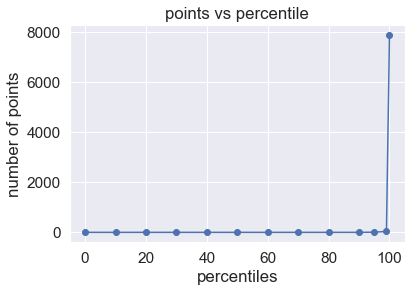

```python
perc=[0,10,20,30,40,50,60,70,80,90,95,99,100]
plt.plot(perc, np.percentile(percent_weight_diff,perc),'bo-')
print(np.percentile(percent_weight_diff, perc))
plt.xlabel('percentiles')
plt.ylabel('number of points')
plt.title('points vs percentile')
plt.show()
```

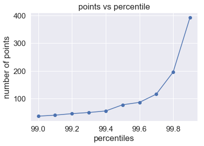

```python
perc= np.arange(99.0,100,0.1)
plt.plot(perc, np.percentile(percent_weight_diff,perc),'bo-')
plt.xlabel('percentiles')
plt.ylabel('number of points')
plt.title('points vs percentile')
plt.show()
```

```python
# print number of weights which changed by 30%
print(percent_weight_diff[np.where(percent_weight_diff > 30)].size)
```

```
659
```

#### Observation

- We can see that as we introduce noise in data the some weights changes significantly. there are 659 Wi's which changed by minimum 30% (taking 30% as threshold)
- Between 99.6 to 100 percentile of points there are large amount of points(we can see it in plot)
- So finally by looking at these ovservation we can say that our L2 regularized BOW vectorized logistic regression model is showing multicollinearity as far as perturbation test is concerned

## Feature importance

```python
clf = LogisticRegression(C= 0.01, penalty= 'l2')
clf.fit(XtrainBOWV,Ytrain)
y_pred = clf.predict(XtestBOWV)
print("F1 score on test set: %0.3f%%"%(f1_score(Ytest, y_pred)*100))
print("AUC score on test set: %0.3f%%"%(roc_auc_score(Ytest, y_pred)*100))
print("Non Zero weights:",np.count_nonzero(clf.coef_))
print("Total weights:",len(clf.coef_[0]))
```

```
F1 score on test set: 94.346%
AUC score on test set: 75.863%
Non Zero weights: 39730
Total weights: 39730
```

```python
def show_most_informative_features(vectorizer, clf, n=15):
    feature_names = vectorizer.get_feature_names()
    coefs_with_fns = sorted(zip(clf.coef_[0], feature_names))
    top = zip(coefs_with_fns[:n], coefs_with_fns[:-(n + 1):-1])
    print("\t\t\tNegative\t\t\t\t\t\tPositive")
    print("________________________________________________________________________________________________")
    for (coef_1, fn_1), (coef_2, fn_2) in top:
        print("\t%.4f\t%-15s\t\t\t\t%.4f\t%-15s" % (coef_1, fn_1, coef_2, fn_2))

show_most_informative_features(bowModel,clf)
#Code Reference:https://stackoverflow.com/questions/11116697/how-to-get-most-informative-features-
#for-scikit-learn-classifiers
```

```
			Negative						Positive
________________________________________________________________________________________________
	-0.3722	disappoint     				0.8316	great
	-0.3075	worst          				0.6557	love
	-0.2317	unfortun       				0.6289	best
	-0.2197	stale          				0.4527	perfect
	-0.2184	aw             				0.4267	delici
	-0.2139	thought        				0.4120	good
	-0.2111	wast           				0.3943	nice
	-0.2093	horribl        				0.3866	excel
	-0.2080	tast           				0.3396	favorit
	-0.2058	terribl        				0.3186	find
	-0.2052	return         				0.3052	wonder
	-0.2020	stick          				0.3019	amaz
	-0.1956	bad            				0.2949	addict
	-0.1954	bland          				0.2500	keep
	-0.1937	would          				0.2460	refresh
```

# TFIDF vectorization

- We will build a model on train text using fit-transform
- Then transform (test) text on model build by train text
- Transformed data will be in the form of sparse matrix
- Then Standardize our data

```python
# generating vetor out of text using tfidf
tfidfModel=TfidfVectorizer()
XtrainTFIDFV= tfidfModel.fit_transform(Xtrain)
XtestTFIDFV= tfidfModel.transform(Xtest)
```

```python
std= StandardScaler(with_mean=False)
XtrainTFIDFV = std.fit_transform(XtrainTFIDFV)
XtestTFIDFV = std.transform(XtestTFIDFV)
```

## Gridsearch CV

```python
logreg=LogisticRegression()
gridSearchParam= {'C':[10**4,10**2,10,1,10**-1,10**-2,10**-4]}
gridSearch= GridSearchCV(logreg,gridSearchParam,cv=10,scoring='roc_auc',n_jobs=-1)
gridSearch.fit(XtrainTFIDFV,Ytrain)
print(gridSearch.best_estimator_)
print('Best Hyperparameter is ',gridSearch.best_params_)
print('Best auc score is ',gridSearch.best_score_)
```

```
LogisticRegression(C=0.0001, class_weight=None, dual=False,
          fit_intercept=True, intercept_scaling=1, max_iter=100,
          multi_class='ovr', n_jobs=1, penalty='l2', random_state=None,
          solver='liblinear', tol=0.0001, verbose=0, warm_start=False)
Best Hyperparameter is  {'C': 0.0001}
Best auc score is  0.9023941144816782
```

```
Text(0.5,1,'Auc score vs C')
```

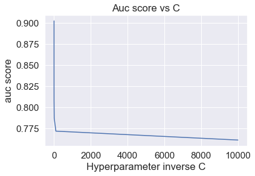

```python
scores = [x[1] for x in gridSearch.grid_scores_]
parameters= gridSearch.param_grid['C']
plt.plot(parameters,scores)
plt.xlabel('Hyperparameter inverse C')
plt.ylabel('auc score')
plt.title('Auc score vs C')
```

### Training and testing with L2 regularization

```
AUC score on test set: 64.545%
Accuracy on test set: 89.287%
Precision on test set: 89.966
Recall on test set: 98.587
F1-Score on test set: 94.080
Non Zero weights: 39730
```

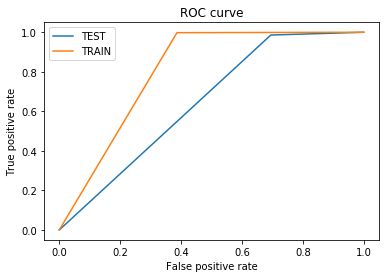

```
Confusion Matrix of test set:
 [ [TN  FP]
 [FN TP] ]
```

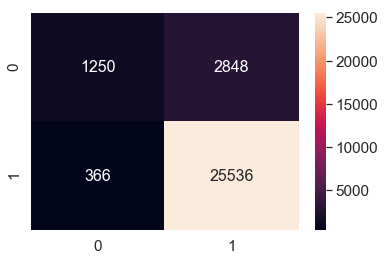

```python
myLogReg(c=0.0001,penalti='l2',xtrn=XtrainTFIDFV,xtst=XtestTFIDFV)
```

### Training and testing with L1 regularization

```
AUC score on test set: 50.000%
Accuracy on test set: 86.340%
Precision on test set: 86.340
Recall on test set: 100.000
F1-Score on test set: 92.669
Non Zero weights: 0
```

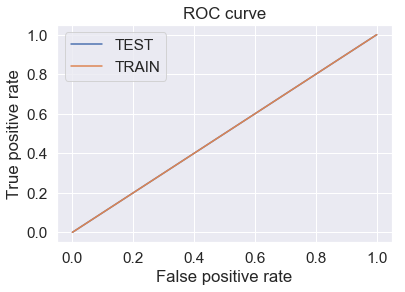

```
Confusion Matrix of test set:
 [ [TN  FP]
 [FN TP] ]
```

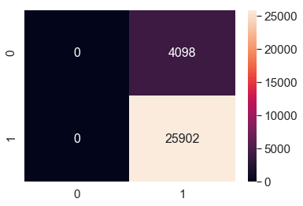

```python
myLogReg(c=0.0001,penalti='l1',xtrn=XtrainTFIDFV,xtst=XtestTFIDFV)
```

## RandomSearch CV

```python
logreg= LogisticRegression()
randSearchParam= {'C':[1000,500,100,50,10,5,1,0.5,0.1,0.05,0.01,0.005,0.001,0.0005,0.0001]}
randsearch= RandomizedSearchCV(logreg,randSearchParam,cv=10,scoring='roc_auc',n_jobs=-1)
randsearch.fit(XtrainTFIDFV,Ytrain)
print(randsearch.best_estimator_)
print('Best Hyperparameter is ',randsearch.best_params_)
print('Best auc score is ',gridSearch.best_score_)
```

```
LogisticRegression(C=0.0005, class_weight=None, dual=False,
          fit_intercept=True, intercept_scaling=1, max_iter=100,
          multi_class='ovr', n_jobs=1, penalty='l2', random_state=None,
          solver='liblinear', tol=0.0001, verbose=0, warm_start=False)
Best Hyperparameter is  {'C': 0.0005}
Best auc score is  0.9023941144816782
```

```
Text(0.5,1,'Auc score vs C')
```

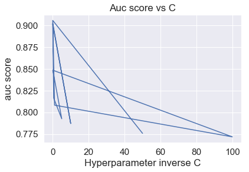

```python
scores = [x[1] for x in randsearch.grid_scores_]
parameters= [x[0]['C'] for x in randsearch.grid_scores_]
plt.plot(parameters,scores)
plt.xlabel('Hyperparameter inverse C')
plt.ylabel('auc score')
plt.title('Auc score vs C')
```

### Training and testing with L2 regularization

```
AUC score on test set: 71.370%
Accuracy on test set: 90.183%
Precision on test set: 91.854
Recall on test set: 97.255
F1-Score on test set: 94.477
Non Zero weights: 39730
```

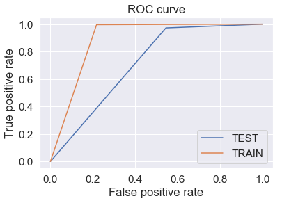

```
Confusion Matrix of test set:
 [ [TN  FP]
 [FN TP] ]
```

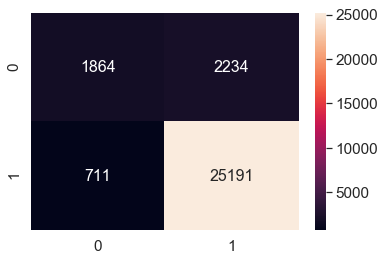

```python
myLogReg(c=0.0005,penalti='l2',xtrn=XtrainTFIDFV,xtst=XtestTFIDFV)
```

### Training and testing with L1 regularization

```
AUC score on test set: 50.254%
Accuracy on test set: 86.407%
Precision on test set: 86.400
Recall on test set: 99.996
F1-Score on test set: 92.702
Non Zero weights: 14
```

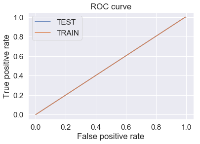

```
Confusion Matrix of test set:
 [ [TN  FP]
 [FN TP] ]
```

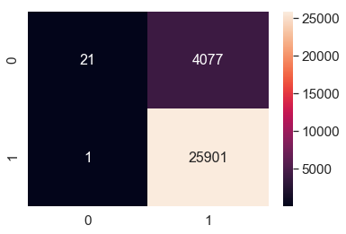

```python
myLogReg(c=0.0005,penalti='l1',xtrn=XtrainTFIDFV,xtst=XtestTFIDFV)
```

## Feature importance L2 , TFIDF

```python
clf = LogisticRegression(C= 0.0005, penalty= 'l2')
clf.fit(XtrainTFIDFV,Ytrain)
y_pred = clf.predict(XtestTFIDFV)
print("F1 score on test set: %0.3f%%"%(f1_score(Ytest, y_pred)*100))
print("AUC score on test set: %0.3f%%"%(roc_auc_score(Ytest, y_pred)*100))
print("Non Zero weights:",np.count_nonzero(clf.coef_))
print("Total weights:",len(clf.coef_[0]))
```

```
F1 score on test set: 94.477%
AUC score on test set: 71.370%
Non Zero weights: 39730
Total weights: 39730
```

```python
def show_most_informative_features(vectorizer, clf, n=10):
    feature_names = vectorizer.get_feature_names()
    coefs_with_fns = sorted(zip(clf.coef_[0], feature_names))
    top = zip(coefs_with_fns[:n], coefs_with_fns[:-(n + 1):-1])
    print("\t\t\tNegative\t\t\t\t\t\tPositive")
    print("________________________________________________________________________________________________")
    for (coef_1, fn_1), (coef_2, fn_2) in top:
        print("\t%.4f\t%-15s\t\t\t\t%.4f\t%-15s" % (coef_1, fn_1, coef_2, fn_2))

show_most_informative_features(tfidfModel,clf)
#Code Reference:https://stackoverflow.com/questions/11116697/how-to-get-most-informative-features-
#for-scikit-learn-classifiers
```

```
			Negative						Positive
________________________________________________________________________________________________
	-0.1648	disappoint     				0.3088	great
	-0.1291	worst          				0.2649	love
	-0.0977	aw             				0.2256	best
	-0.0942	stale          				0.1806	good
	-0.0919	terribl        				0.1589	delici
	-0.0917	horribl        				0.1467	excel
	-0.0915	unfortun       				0.1441	perfect
	-0.0905	bland          				0.1351	favorit
	-0.0865	wast           				0.1333	nice
	-0.0852	return         				0.1294	find
```

# Avg W2V vectorization

```python
import gensim
# training our gensim model on our train text
import re
import string
def cleanhtml(sentance): #substitute expression contained in <> with ' '
    cleaned= re.sub(re.compile('<.*?>'),' ',sentance)
    return cleaned
#function for removing punctuations chars
def cleanpunc(sentance):
    cleaned= re.sub(r'[?|!|\'|"|#]',r'',sentance)
    cleaned= re.sub(r'[.|,|)|(|\|/]',r'',sentance)
    return cleaned
i=0
lists=[]

for sent in Xtrain.values:
    filtered_sentence=[]
    sent=cleanhtml(sent)
    for w in sent.split():
        for cleaned_words in cleanpunc(w).split():
            if(cleaned_words.isalpha()):
                filtered_sentence.append(cleaned_words.lower())
            else:
                continue
    lists.append(filtered_sentence)


w2v_model= gensim.models.Word2Vec(lists,min_count=5,size=50,workers=4)
print(len(list(w2v_model.wv.vocab)))
```

```
10351
```

```python
w2v_words = list(w2v_model.wv.vocab)
```

```python
# converting list of sentance into list of list of words
# then to vector using avg w2v
# function to convert list of list of words to vect using avg w2v
def w2vVect(X):
    '''
    This function takes list of sentance as input (X) and convert it into
    list of list of words and then feed it into our gensim model to get vector
    and then take its average, finally returns sent_vectors(vector of sentance)
    *************GENSIM MODEL WAS TRAINED ON TRAINDATA***************
    '''

    lists=[]
    for sent in X.values:
        filtered_sentence=[]
        sent=cleanhtml(sent)
        for w in sent.split():
            for cleaned_words in cleanpunc(w).split():
                if(cleaned_words.isalpha()):
                    filtered_sentence.append(cleaned_words.lower())
                else:
                    continue
        lists.append(filtered_sentence)

    sent_vectors = [];
    for sent in lists:
        sent_vec = np.zeros(50)
        cnt_words =0;
        for word in sent:
            if word in w2v_words:
                vec = w2v_model.wv[word]
                sent_vec += vec
                cnt_words += 1
        if cnt_words != 0:
            sent_vec /= cnt_words
        sent_vectors.append(sent_vec)
    return sent_vectors
```

```python
# Vectorizing our data
XtrainW2VV= w2vVect(Xtrain)
XtestW2VV= w2vVect(Xtest)
```

```python
#Standardizing vectors
std = StandardScaler(with_mean=False).fit(XtrainW2VV)
XtrainW2VV = std.transform(XtrainW2VV)
XtestW2VV = std.transform(XtestW2VV)
```

## Gridsearch CV

```python
logreg=LogisticRegression()
gridSearchParam= {'C':[10**4,10**2,10,1,10**-1,10**-2,10**-4]}
gridSearch= GridSearchCV(logreg,gridSearchParam,cv=10,scoring='roc_auc',n_jobs=-1)
gridSearch.fit(XtrainW2VV,Ytrain)
print(gridSearch.best_estimator_)
print('Best Hyperparameter is ',gridSearch.best_params_)
print('Best auc score is ',gridSearch.best_score_)
```

```
LogisticRegression(C=1, class_weight=None, dual=False, fit_intercept=True,
          intercept_scaling=1, max_iter=100, multi_class='ovr', n_jobs=1,
          penalty='l2', random_state=None, solver='liblinear', tol=0.0001,
          verbose=0, warm_start=False)
Best Hyperparameter is  {'C': 1}
Best auc score is  0.8846268174383332
```

```
Text(0.5,1,'Auc score vs C')
```

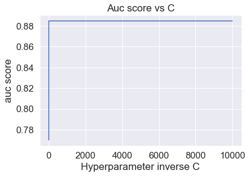

```python
scores = [x[1] for x in gridSearch.grid_scores_]
parameters= gridSearch.param_grid['C']
plt.plot(parameters,scores)
plt.xlabel('Hyperparameter inverse C')
plt.ylabel('auc score')
plt.title('Auc score vs C')
```

### Training and testing with L2 regularization

```
AUC score on test set: 65.745%
Accuracy on test set: 89.107%
Precision on test set: 90.308
Recall on test set: 97.888
F1-Score on test set: 93.946
Non Zero weights: 50
```

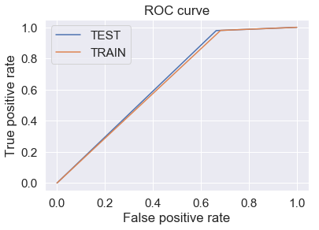

```
Confusion Matrix of test set:
 [ [TN  FP]
 [FN TP] ]
```

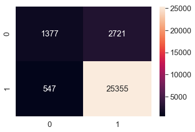

```python
myLogReg(c=1,penalti='l2',xtrn=XtrainW2VV,xtst=XtestW2VV)
```

### Training and testing with L1 regularization

```
AUC score on test set: 65.723%
Accuracy on test set: 89.103%
Precision on test set: 90.302
Recall on test set: 97.892
F1-Score on test set: 93.944
Non Zero weights: 50
```

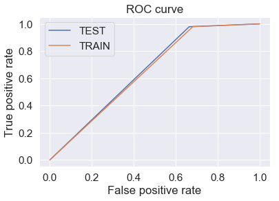

```
Confusion Matrix of test set:
 [ [TN  FP]
 [FN TP] ]
```

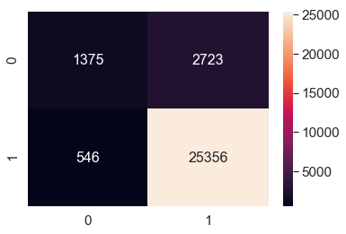

```python
myLogReg(c=1,penalti='l1',xtrn=XtrainW2VV,xtst=XtestW2VV)
```

## RandomSearch CV

```python
logreg= LogisticRegression()
randSearchParam= {'C':[1000,500,100,50,10,5,1,0.5,0.1,0.05,0.01,0.005,0.001,0.0005,0.0001]}
randsearch= RandomizedSearchCV(logreg,randSearchParam,cv=10,scoring='roc_auc',n_jobs=-1)
randsearch.fit(XtrainW2VV,Ytrain)
print(randsearch.best_estimator_)
print('Best Hyperparameter is ',randsearch.best_params_)
print('Best auc score is ',gridSearch.best_score_)
```

```
LogisticRegression(C=5, class_weight=None, dual=False, fit_intercept=True,
          intercept_scaling=1, max_iter=100, multi_class='ovr', n_jobs=1,
          penalty='l2', random_state=None, solver='liblinear', tol=0.0001,
          verbose=0, warm_start=False)
Best Hyperparameter is  {'C': 5}
Best auc score is  0.8846268174383332
```

```
Text(0.5,1,'Auc score vs C')
```

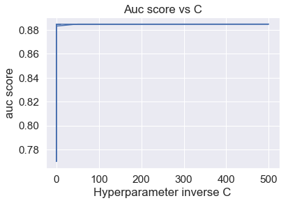

```python
scores = [x[1] for x in randsearch.grid_scores_]
parameters= [x[0]['C'] for x in randsearch.grid_scores_]
plt.plot(parameters,scores)
plt.xlabel('Hyperparameter inverse C')
plt.ylabel('auc score')
plt.title('Auc score vs C')
```

### Training and testing with L2 regularization

```
AUC score on test set: 65.717%
Accuracy on test set: 89.093%
Precision on test set: 90.301
Recall on test set: 97.880
F1-Score on test set: 93.938
Non Zero weights: 50
```

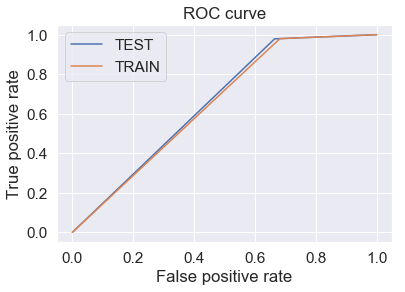

```
Confusion Matrix of test set:
 [ [TN  FP]
 [FN TP] ]
```

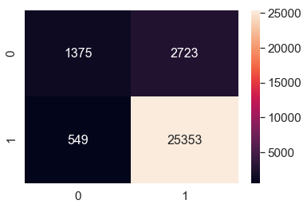

```python
myLogReg(c=5,penalti='l2',xtrn=XtrainW2VV,xtst=XtestW2VV)
```

### Training and testing with L1 regularization

```
AUC score on test set: 65.745%
Accuracy on test set: 89.107%
Precision on test set: 90.308
Recall on test set: 97.888
F1-Score on test set: 93.946
Non Zero weights: 50
```

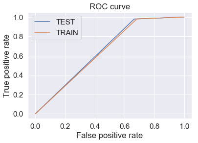

```
Confusion Matrix of test set:
 [ [TN  FP]
 [FN TP] ]
```

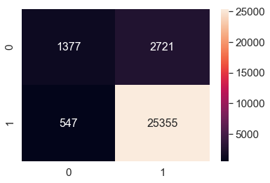

```python
myLogReg(c=5,penalti='l1',xtrn=XtrainW2VV,xtst=XtestW2VV)
```

# tfidf-weighted avg w2v vectorization

```python
tfmodel=TfidfVectorizer(max_features=2000)
tf_idf_matrix = tfmodel.fit_transform(Xtrain.values)
tfidf_feat=tfmodel.get_feature_names()
dictionary = {k:v for (k,v) in zip(tfmodel.get_feature_names(), list(tfmodel.idf_))}
```

```python
def tfidfw2vVect(X):
    '''
    This function converts list of sentance into list of list of words and then
    finally applies average-tfidf-w2w to get final sentance vector
    w2v model and w2v words already made during w2v vectorization part
    '''
    lists=[]
    for sent in X.values:
        filtered_sentence=[]
        sent=cleanhtml(sent)
        for w in sent.split():
            for cleaned_words in cleanpunc(w).split():
                if(cleaned_words.isalpha()):
                    filtered_sentence.append(cleaned_words.lower())
                else:
                    continue
        lists.append(filtered_sentence)

    tfidfw2v_sent_vectors = []; # the tfidf-w2v for each sentence/review is stored in this list
    row=0;
    for sent in lists: # for each review/sentence
        sent_vec = np.zeros(50) # as word vectors are of zero length
        weight_sum =0; # num of words with a valid vector in the sentence/review
        for word in sent: # for each word in a review/sentence
            try:
                if word in w2v_words:
                    vec = w2v_model.wv[word]
                    #tf_idf = tf_idf_matrix[row, tfidf_feat.index(word)]
                    #to reduce the computation we are
                    #dictionary[word] = idf value of word in whole courpus
                    #sent.count(word) = tf valeus of word in this review
                    tf_idf = (dictionary[word])*((sent.count(word))/len(sent))
                    sent_vec += (vec * tf_idf)
                    weight_sum += tf_idf
            except:
                pass
        if weight_sum != 0:
            sent_vec /= weight_sum
        tfidfw2v_sent_vectors.append(sent_vec)
        row += 1
    # converting nan and infinte values in vect to digit
    tfidfw2v_sent_vectors= np.nan_to_num(tfidfw2v_sent_vectors)
    return tfidfw2v_sent_vectors
```

```python
# feeding text data and recieving vectorized data
XtrainTFIDFW2VV= tfidfw2vVect(Xtrain)
XtestTFIDFW2VV= tfidfw2vVect(Xtest)
```

```python
#Standardizing vectors
std = StandardScaler(with_mean=False).fit(XtrainTFIDFW2VV)
XtrainTFIDFW2VV = std.transform(XtrainTFIDFW2VV)
XtestTFIDFW2VV = std.transform(XtestTFIDFW2VV)
```

## Gridsearch CV

```python
logreg=LogisticRegression()
gridSearchParam= {'C':[10**4,10**2,10,1,10**-1,10**-2,10**-4]}
gridSearch= GridSearchCV(logreg,gridSearchParam,cv=10,scoring='roc_auc',n_jobs=-1)
gridSearch.fit(XtrainTFIDFW2VV,Ytrain)
print(gridSearch.best_estimator_)
print('Best Hyperparameter is ',gridSearch.best_params_)
print('Best auc score is ',gridSearch.best_score_)
```

```
LogisticRegression(C=0.01, class_weight=None, dual=False, fit_intercept=True,
          intercept_scaling=1, max_iter=100, multi_class='ovr', n_jobs=1,
          penalty='l2', random_state=None, solver='liblinear', tol=0.0001,
          verbose=0, warm_start=False)
Best Hyperparameter is  {'C': 0.01}
Best auc score is  0.8578684300155411
```

```
Text(0.5,1,'Auc score vs C')
```

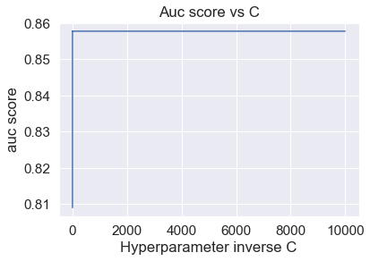

```python
scores = [x[1] for x in gridSearch.grid_scores_]
parameters= gridSearch.param_grid['C']
plt.plot(parameters,scores)
plt.xlabel('Hyperparameter inverse C')
plt.ylabel('auc score')
plt.title('Auc score vs C')
```

### Training and testing with L2 regularization

```
AUC score on test set: 61.235%
Accuracy on test set: 88.183%
Precision on test set: 89.123
Recall on test set: 98.313
F1-Score on test set: 93.492
Non Zero weights: 50
```

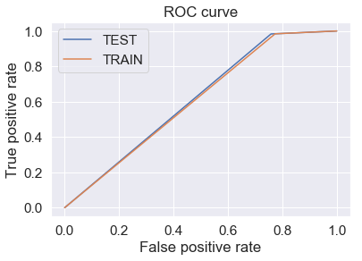

```
Confusion Matrix of test set:
 [ [TN  FP]
 [FN TP] ]
```

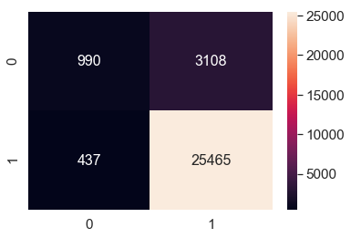

```python
myLogReg(c=0.01,penalti='l2',xtrn=XtrainTFIDFW2VV,xtst=XtestTFIDFW2VV)
```

### Training and testing with L1 regularization

```
AUC score on test set: 60.003%
Accuracy on test set: 88.007%
Precision on test set: 88.803
Recall on test set: 98.533
F1-Score on test set: 93.415
Non Zero weights: 43
```

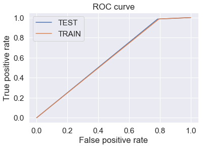

```
Confusion Matrix of test set:
 [ [TN  FP]
 [FN TP] ]
```

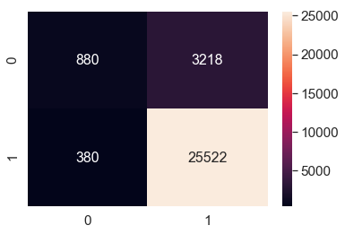

```python
myLogReg(c=0.01,penalti='l1',xtrn=XtrainTFIDFW2VV,xtst=XtestTFIDFW2VV)
```

## RandomSearch CV

```python
logreg= LogisticRegression()
randSearchParam= {'C':[1000,500,100,50,10,5,1,0.5,0.1,0.05,0.01,0.005,0.001,0.0005,0.0001]}
randsearch= RandomizedSearchCV(logreg,randSearchParam,cv=10,scoring='roc_auc',n_jobs=-1)
randsearch.fit(XtrainTFIDFW2VV,Ytrain)
print(randsearch.best_estimator_)
print('Best Hyperparameter is ',randsearch.best_params_)
print('Best auc score is ',gridSearch.best_score_)
```

```
LogisticRegression(C=0.05, class_weight=None, dual=False, fit_intercept=True,
          intercept_scaling=1, max_iter=100, multi_class='ovr', n_jobs=1,
          penalty='l2', random_state=None, solver='liblinear', tol=0.0001,
          verbose=0, warm_start=False)
Best Hyperparameter is  {'C': 0.05}
Best auc score is  0.8578684300155411
```

```
Text(0.5,1,'Auc score vs C')
```

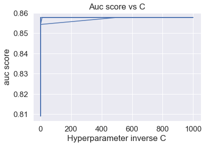

```python
scores = [x[1] for x in randsearch.grid_scores_]
parameters= [x[0]['C'] for x in randsearch.grid_scores_]
plt.plot(parameters,scores)
plt.xlabel('Hyperparameter inverse C')
plt.ylabel('auc score')
plt.title('Auc score vs C')
```

### Training and testing with L2 regularization

```
AUC score on test set: 61.725%
Accuracy on test set: 88.230%
Precision on test set: 89.252
Recall on test set: 98.193
F1-Score on test set: 93.509
Non Zero weights: 50
```

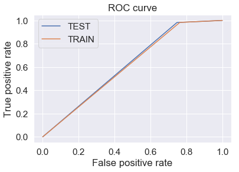

```
Confusion Matrix of test set:
 [ [TN  FP]
 [FN TP] ]
```

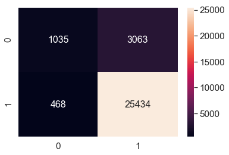

```python
myLogReg(c=0.05,penalti='l2',xtrn=XtrainTFIDFW2VV,xtst=XtestTFIDFW2VV)
```

### Training and testing with L1 regularization

```
AUC score on test set: 61.534%
Accuracy on test set: 88.220%
Precision on test set: 89.201
Recall on test set: 98.251
F1-Score on test set: 93.507
Non Zero weights: 49
```

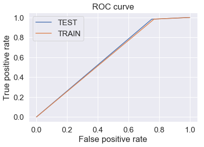

```
Confusion Matrix of test set:
 [ [TN  FP]
 [FN TP] ]
```

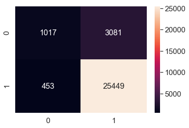

```python
myLogReg(c=0.05,penalti='l1',xtrn=XtrainTFIDFW2VV,xtst=XtestTFIDFW2VV)
```

# Summary

## GridSearchCV

| Vectorizer & Regularizer | optimal C | AUC | Accuracy | Precision | recall | F1 | weights |
| --- | --- | --- | --- | --- | --- | --- | --- |
| BOW L2 | 0.01 | 75.875 | 90.123 | 93.244 | 95.479 | 94.348 | 39730 |
| BOW L1 | 0.01 | 72.363 | 91.100 | 92.072 | 98.143 | 95.010 | 3894 |
| TFIDF L2 | 0.0001 | 64.545 | 89.287 | 89.966 | 98.587 | 94.080 | 39730 |
| TFIDF L1 | 0.0001 | 50.000 | 86.340 | 86.340 | 100.000 | 92.669 | 0 |
| W2V L2 | 1 | 65.745 | 89.107 | 90.308 | 97.888 | 93.946 | 50 |
| W2V L1 | 1 | 65.723 | 89.103 | 90.302 | 97.892 | 93.944 | 50 |
| TFIDF-W2v L2 | 0.01 | 61.235 | 88.183 | 89.123 | 98.313 | 93.492 | 50 |
| TFIDF-W2V L1 | 0.01 | 60.003 | 88.007 | 88.803 | 98.533 | 93.415 | 43 |

## RandomizedSearchCv

| Vectorizer & Regularizer | optimal C | AUC | Accuracy | Precision | recall | F1 | weights |
| --- | --- | --- | --- | --- | --- | --- | --- |
| BOW L2 | 0.001 | 73.976 | 90.977 | 92.567 | 97.367 | 94.907 | 39730 |
| BOW L1 | 0.001 | 54.673 | 87.457 | 87.459 | 99.780 | 93.214 | 50 |
| TFIDF L2 | 0.0005 | 71.370 | 90.183 | 91.854 | 97.255 | 94.477 | 39730 |
| TFIDF L1 | 0.0005 | 50.254 | 86.407 | 86.400 | 99.996 | 92.702 | 14 |
| W2V L2 | 5 | 65.717 | 89.093 | 90.301 | 97.880 | 93.938 | 50 |
| W2V L1 | 5 | 65.745 | 89.107 | 90.308 | 97.888 | 93.946 | 50 |
| TFIDF-W2v L2 | 0.05 | 61.725 | 88.230 | 89.252 | 98.193 | 93.509 | 50 |
| TFIDF-W2V L1 | 0.05 | 61.534 | 88.220 | 89.201 | 98.251 | 93.507 | 49 |

## Conclusion

- The best model according to AUC metric is BOW with L2 regularizer and with optimal C of 0.01
- RandomizedSearchCV is as affective as GridsearchCV
- **Sparsity** is inversly proportional C and directly proportional to lambda
- We saw that L2 regularized logistic regression model from BOW vector was having **multicollinear** features
- Nonzero weights counts decreased as C decreased
- Below we can see how good our logistic regression model predicted 'Positive' and 'Negative' words

  ```
       Negative                     Positive
  ```

```
-0.3722 disappoint                  0.8316  great
-0.3075 worst                       0.6557  love
-0.2317 unfortun                    0.6289  best
-0.2197 stale                       0.4527  perfect
-0.2184 aw                          0.4267  delici
-0.2139 thought                     0.4120  good
-0.2111 wast                        0.3943  nice
-0.2093 horribl                     0.3866  excel
-0.2080 tast                        0.3396  favorit
-0.2058 terribl                     0.3186  find
-0.2052 return                      0.3052  wonder
-0.2020 stick                       0.3019  amaz
-0.1956 bad                         0.2949  addict
-0.1954 bland                       0.2500  keep
-0.1937 would                       0.2460  refresh
```

```python
print('end\n\n\n\n\n')
```

```
end
```